# SMU DS - Crypto_Clustering - Model19 - Challenge

```python
# Import required libraries and dependencies

# standard data science
import pandas as pd
import numpy as np
import matplotlib.pyplot as plt

# fancy plotting lib
import hvplot.pandas

# preprocessing
from sklearn.decomposition import PCA
from sklearn.preprocessing import StandardScaler, MinMaxScaler

# Algorithms
from sklearn.manifold import TSNE
from sklearn.cluster import KMeans, AgglomerativeClustering

# Metrics
from sklearn.metrics import silhouette_samples, silhouette_score
```

```python
# Load the data into a Pandas DataFrame
df_market_data = pd.read_csv(
    "Resources/crypto_market_data.csv",
    index_col="coin_id")

# Display sample data
df_market_data.head(10)
```

| coin_id | price_change_percentage_24h | price_change_percentage_7d | price_change_percentage_14d | price_change_percentage_30d | price_change_percentage_60d | price_change_percentage_200d | price_change_percentage_1y |
| --- | --- | --- | --- | --- | --- | --- | --- |
| bitcoin | 1.08388 | 7.60278 | 6.57509 | 7.67258 | -3.25185 | 83.51840 | 37.51761 |
| ethereum | 0.22392 | 10.38134 | 4.80849 | 0.13169 | -12.88890 | 186.77418 | 101.96023 |
| tether | -0.21173 | 0.04935 | 0.00640 | -0.04237 | 0.28037 | -0.00542 | 0.01954 |
| ripple | -0.37819 | -0.60926 | 2.24984 | 0.23455 | -17.55245 | 39.53888 | -16.60193 |
| bitcoin-cash | 2.90585 | 17.09717 | 14.75334 | 15.74903 | -13.71793 | 21.66042 | 14.49384 |
| binancecoin | 2.10423 | 12.85511 | 6.80688 | 0.05865 | 36.33486 | 155.61937 | 69.69195 |
| chainlink | -0.23935 | 20.69459 | 9.30098 | -11.21747 | -43.69522 | 403.22917 | 325.13186 |
| cardano | 0.00322 | 13.99302 | 5.55476 | 10.10553 | -22.84776 | 264.51418 | 156.09756 |
| litecoin | -0.06341 | 6.60221 | 7.28931 | 1.21662 | -17.23960 | 27.49919 | -12.66408 |
| bitcoin-cash-sv | 0.92530 | 3.29641 | -1.86656 | 2.88926 | -24.87434 | 7.42562 | 93.73082 |

```python
df = df_market_data
```

```python
df.info()
```

```
<class 'pandas.core.frame.DataFrame'>
Index: 41 entries, bitcoin to digibyte
Data columns (total 7 columns):
 #   Column                        Non-Null Count  Dtype
---  ------                        --------------  -----
 0   price_change_percentage_24h   41 non-null     float64
 1   price_change_percentage_7d    41 non-null     float64
 2   price_change_percentage_14d   41 non-null     float64
 3   price_change_percentage_30d   41 non-null     float64
 4   price_change_percentage_60d   41 non-null     float64
 5   price_change_percentage_200d  41 non-null     float64
 6   price_change_percentage_1y    41 non-null     float64
dtypes: float64(7)
memory usage: 2.6+ KB
```

```python
# Generate summary statistics
df.describe()
```

|  | price_change_percentage_24h | price_change_percentage_7d | price_change_percentage_14d | price_change_percentage_30d | price_change_percentage_60d | price_change_percentage_200d | price_change_percentage_1y |
| --- | --- | --- | --- | --- | --- | --- | --- |
| count | 41.000000 | 41.000000 | 41.000000 | 41.000000 | 41.000000 | 41.000000 | 41.000000 |
| mean | -0.269686 | 4.497147 | 0.185787 | 1.545693 | -0.094119 | 236.537432 | 347.667956 |
| std | 2.694793 | 6.375218 | 8.376939 | 26.344218 | 47.365803 | 435.225304 | 1247.842884 |
| min | -13.527860 | -6.094560 | -18.158900 | -34.705480 | -44.822480 | -0.392100 | -17.567530 |
| 25% | -0.608970 | 0.047260 | -5.026620 | -10.438470 | -25.907990 | 21.660420 | 0.406170 |
| 50% | -0.063410 | 3.296410 | 0.109740 | -0.042370 | -7.544550 | 83.905200 | 69.691950 |
| 75% | 0.612090 | 7.602780 | 5.510740 | 4.578130 | 0.657260 | 216.177610 | 168.372510 |
| max | 4.840330 | 20.694590 | 24.239190 | 140.795700 | 223.064370 | 2227.927820 | 7852.089700 |

```python
# Plotting data to see what's in the DataFrame
df.hvplot.line(
    width=800,
    height=400,
    rot=90
)
```

[interactive chart not shown]

# as a reference note - scalling help our data, specifically with the 200 day and 1yr change columns

# Prepare the Data

```python
df.columns
```

```
Index(['price_change_percentage_24h', 'price_change_percentage_7d',
       'price_change_percentage_14d', 'price_change_percentage_30d',
       'price_change_percentage_60d', 'price_change_percentage_200d',
       'price_change_percentage_1y'],
      dtype='object')
```

```python
# Use the `StandardScaler()` module from scikit-learn to normalize the data from the CSV file
```

```python
# Create a DataFrame with the scaled data
num_cols = ['price_change_percentage_24h', 'price_change_percentage_7d',
       'price_change_percentage_14d', 'price_change_percentage_30d',
       'price_change_percentage_60d', 'price_change_percentage_200d',
       'price_change_percentage_1y']
df_num = df.loc[:, num_cols]
scaler = StandardScaler().fit(df_num)

df_scale = scaler.transform(df_num)
df_scale = pd.DataFrame(df_scale, columns=num_cols, index=df.index)
df_scale.head()
```

| coin_id | price_change_percentage_24h | price_change_percentage_7d | price_change_percentage_14d | price_change_percentage_30d | price_change_percentage_60d | price_change_percentage_200d | price_change_percentage_1y |
| --- | --- | --- | --- | --- | --- | --- | --- |
| bitcoin | 0.508529 | 0.493193 | 0.772200 | 0.235460 | -0.067495 | -0.355953 | -0.251637 |
| ethereum | 0.185446 | 0.934445 | 0.558692 | -0.054341 | -0.273483 | -0.115759 | -0.199352 |
| tether | 0.021774 | -0.706337 | -0.021680 | -0.061030 | 0.008005 | -0.550247 | -0.282061 |
| ripple | -0.040764 | -0.810928 | 0.249458 | -0.050388 | -0.373164 | -0.458259 | -0.295546 |
| bitcoin-cash | 1.193036 | 2.000959 | 1.760610 | 0.545842 | -0.291203 | -0.499848 | -0.270317 |

```python
df_scale.describe()
```

|  | price_change_percentage_24h | price_change_percentage_7d | price_change_percentage_14d | price_change_percentage_30d | price_change_percentage_60d | price_change_percentage_200d | price_change_percentage_1y |
| --- | --- | --- | --- | --- | --- | --- | --- |
| count | 41.000000 | 4.100000e+01 | 4.100000e+01 | 4.100000e+01 | 4.100000e+01 | 4.100000e+01 | 4.100000e+01 |
| mean | 0.000000 | 1.895503e-16 | 2.707861e-17 | 2.978647e-17 | -5.415722e-18 | -1.326852e-16 | 4.197185e-17 |
| std | 1.012423 | 1.012423e+00 | 1.012423e+00 | 1.012423e+00 | 1.012423e+00 | 1.012423e+00 | 1.012423e+00 |
| min | -4.981042 | -1.682027e+00 | -2.217108e+00 | -1.393153e+00 | -9.560487e-01 | -5.511464e-01 | -2.963296e-01 |
| 25% | -0.127467 | -7.066688e-01 | -6.299628e-01 | -4.605580e-01 | -5.517599e-01 | -4.998478e-01 | -2.817468e-01 |
| 50% | 0.077497 | -1.906843e-01 | -9.190922e-03 | -6.103015e-02 | -1.592496e-01 | -3.550537e-01 | -2.255326e-01 |
| 75% | 0.331280 | 4.931931e-01 | 6.435649e-01 | 1.165382e-01 | 1.606038e-02 | -4.736110e-02 | -1.454693e-01 |
| max | 1.919812 | 2.572251e+00 | 2.907054e+00 | 5.351455e+00 | 4.769913e+00 | 4.632380e+00 | 6.088625e+00 |

# TSNE plots

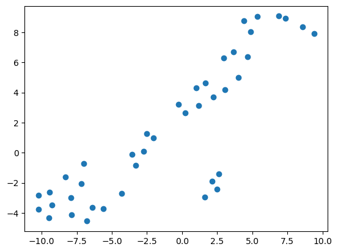

```python
# TSNE plots
# (UNSCALED)
X = df_num.to_numpy()
X_embedded = TSNE(perplexity=10).fit_transform(X)

plt.scatter(X_embedded[:, 0], X_embedded[:, 1])
plt.show()
```

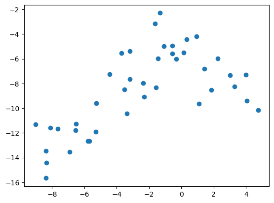

```python
# (STANDARD Scaler TSNE)
X = df_scale.to_numpy()
X_embedded = TSNE(perplexity=10).fit_transform(X)

plt.scatter(X_embedded[:, 0], X_embedded[:, 1])
plt.show()
```

### Find the Best Value for k Using the Original Data.

```python
import warnings
warnings.filterwarnings("ignore")
```

```python
# Create a list with the number of k-values from 1 to 11
```

```python
k = list(range(1,12))
k
```

```
[1, 2, 3, 4, 5, 6, 7, 8, 9, 10, 11]
```

```python
# Here is "DO K MEANS"
inertia = []
silhouettes = []
k = list(range(2, 12))

for i in k:
    print(f"Processing K={i}")
    k_model = KMeans(n_clusters=i, random_state=1)
    k_model.fit(df_scale) # fit on the scaled data
    inertia.append(k_model.inertia_)

    preds = k_model.predict(df_scale)
    silhouette_avg = silhouette_score(df_scale, preds)
    silhouettes.append(silhouette_avg)
```

```
Processing K=2
Processing K=3
Processing K=4
Processing K=5
Processing K=6
Processing K=7
Processing K=8
Processing K=9
Processing K=10
Processing K=11
```

```python
# Define a DataFrame to hold the values for k and the corresponding inertia
elbow_data = {"k": k, "silouehette": silhouettes, "inertia": inertia}
df_elbow = pd.DataFrame(elbow_data)
df_elbow["inertia_diff"] = df_elbow.inertia.diff()
```

```python
# Review the DataFrame
df_elbow
```

|  | k | silouehette | inertia | inertia_diff |
| --- | --- | --- | --- | --- |
| 0 | 2 | 0.651576 | 195.820218 | NaN |
| 1 | 3 | 0.702822 | 123.190482 | -72.629736 |
| 2 | 4 | 0.314482 | 79.022435 | -44.168046 |
| 3 | 5 | 0.251511 | 65.405923 | -13.616512 |
| 4 | 6 | 0.293221 | 52.933559 | -12.472365 |
| 5 | 7 | 0.237507 | 47.983124 | -4.950435 |
| 6 | 8 | 0.256063 | 37.288187 | -10.694937 |
| 7 | 9 | 0.205528 | 33.061685 | -4.226502 |
| 8 | 10 | 0.238327 | 28.779752 | -4.281932 |
| 9 | 11 | 0.216166 | 25.248499 | -3.531253 |

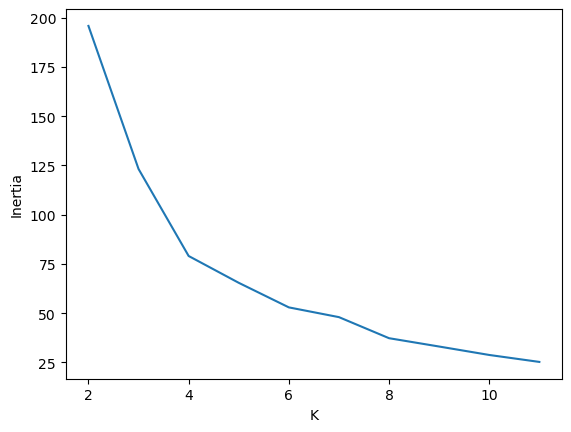

```python
plt.plot(df_elbow.k, df_elbow.inertia)
plt.xlabel("K")
plt.ylabel("Inertia")
plt.show()
```

# Make TSNE for 3

```python
# Make TSNE for 3
model = KMeans(n_clusters=3, random_state=1)
# Fit the model
model.fit(df_scale)
```

```
KMeans(n_clusters=3, random_state=1)
```

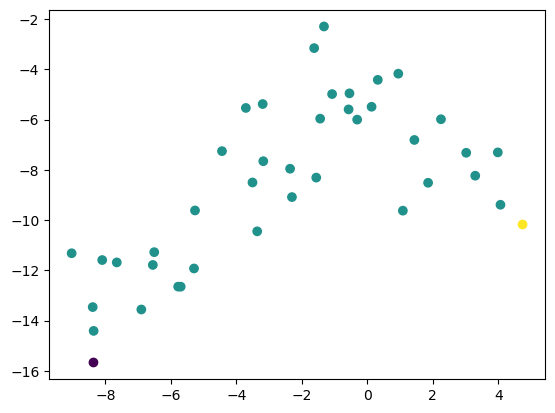

```python
# Make predictions
preds = model.predict(df_scale)

X = df_scale.to_numpy()
X_embedded = TSNE(perplexity=10).fit_transform(X)

plt.scatter(X_embedded[:, 0], X_embedded[:, 1], c=preds)
plt.show()
```

# Make TSNE for 4

```python
# Make TSNE for 4
model = KMeans(n_clusters=4, random_state=1)

# Fit the model
model.fit(df_scale)

# Make predictions
preds = model.predict(df_scale)

X = df_scale.to_numpy()
X_embedded = TSNE(perplexity=10).fit_transform(X)
```

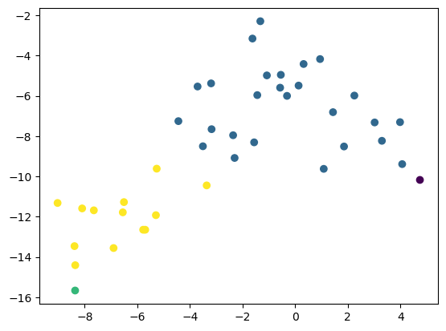

```python
plt.scatter(X_embedded[:, 0], X_embedded[:, 1], c=preds)
plt.show()
```

```python
df_copy = df_scale.copy()
df_copy["cluster"] = preds
df_copy.cluster.value_counts()
```

```
1    26
3    13
0     1
2     1
Name: cluster, dtype: int64
```

```python
df_copy.loc[df_copy.cluster.isin([0, 2])]
```

| coin_id | price_change_percentage_24h | price_change_percentage_7d | price_change_percentage_14d | price_change_percentage_30d | price_change_percentage_60d | price_change_percentage_200d | price_change_percentage_1y | cluster |
| --- | --- | --- | --- | --- | --- | --- | --- | --- |
| ethlend | -4.981042 | -0.045178 | -1.206956 | -1.212126 | 0.047736 | 4.632380 | 6.088625 | 0 |
| celsius-degree-token | 1.045530 | -0.618328 | 2.907054 | 5.351455 | 4.769913 | 3.148875 | 1.348488 | 2 |

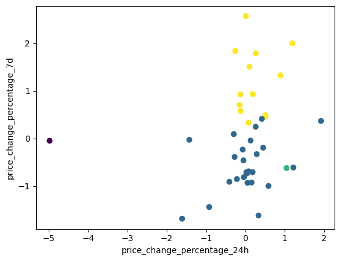

```python
plt.scatter(df_copy.price_change_percentage_24h, df_copy.price_change_percentage_7d, c=df_copy.cluster)
plt.ylabel("price_change_percentage_7d")
plt.xlabel("price_change_percentage_24h")
plt.show()
```

#### Answer the following question:

**Question:** What is the best value for `k`?

**Answer:** From the scatter plots, it's a little hard to tell given the variability and quantity of the data (zooming in helps), but it appears that the optimal value for k, the nubmer of clusters, is 4.

# Cluster Cryptocurrencies with K-means Using the Original Data

# Optimize Clusters with Principal Component Analysis.

```python
df_scale.corr()
```

|  | price_change_percentage_24h | price_change_percentage_7d | price_change_percentage_14d | price_change_percentage_30d | price_change_percentage_60d | price_change_percentage_200d | price_change_percentage_1y |
| --- | --- | --- | --- | --- | --- | --- | --- |
| price_change_percentage_24h | 1.000000 | 0.169659 | 0.279682 | 0.292563 | 0.136974 | -0.541190 | -0.750630 |
| price_change_percentage_7d | 0.169659 | 1.000000 | 0.538294 | 0.056899 | -0.145099 | -0.052533 | -0.038424 |
| price_change_percentage_14d | 0.279682 | 0.538294 | 1.000000 | 0.658040 | 0.376108 | -0.039086 | -0.116632 |
| price_change_percentage_30d | 0.292563 | 0.056899 | 0.658040 | 1.000000 | 0.745248 | 0.324777 | 0.016078 |
| price_change_percentage_60d | 0.136974 | -0.145099 | 0.376108 | 0.745248 | 1.000000 | 0.499102 | 0.211242 |
| price_change_percentage_200d | -0.541190 | -0.052533 | -0.039086 | 0.324777 | 0.499102 | 1.000000 | 0.879873 |
| price_change_percentage_1y | -0.750630 | -0.038424 | -0.116632 | 0.016078 | 0.211242 | 0.879873 | 1.000000 |

```python
# Create the PCA model instance where n_components= len(num_cols)
n_comps = len(df_scale.columns)
pca = PCA(n_components=n_comps)
```

```python
# fit/transform
df_pca = pca.fit_transform(df_scale)
```

```python
df_pca = pd.DataFrame(df_pca, columns=[f"PCA_{x}" for x in range(1, n_comps + 1)], index=df.index)
df_pca.head()
```

| coin_id | PCA_1 | PCA_2 | PCA_3 | PCA_4 | PCA_5 | PCA_6 | PCA_7 |
| --- | --- | --- | --- | --- | --- | --- | --- |
| bitcoin | -0.600667 | 0.842760 | 0.461595 | -0.109151 | -0.033786 | -0.225703 | 0.006595 |
| ethereum | -0.458261 | 0.458466 | 0.952877 | 0.095100 | 0.014588 | 0.034158 | 0.109593 |
| tether | -0.433070 | -0.168126 | -0.641752 | -0.470282 | 0.115300 | -0.127710 | -0.086857 |
| ripple | -0.471835 | -0.222660 | -0.479053 | -0.737473 | -0.148641 | -0.273472 | 0.134870 |
| bitcoin-cash | -1.157800 | 2.041209 | 1.859715 | 0.236479 | -0.191787 | -0.411513 | -0.070411 |

```python
df_pca.corr()
```

|  | PCA_1 | PCA_2 | PCA_3 | PCA_4 | PCA_5 | PCA_6 | PCA_7 |
| --- | --- | --- | --- | --- | --- | --- | --- |
| PCA_1 | 1.000000e+00 | 2.599562e-16 | 1.095974e-16 | 7.434809e-17 | -1.343605e-17 | -2.088502e-16 | 1.230570e-17 |
| PCA_2 | 2.599562e-16 | 1.000000e+00 | -3.322026e-16 | -1.326485e-16 | -2.980973e-17 | -1.292298e-16 | -2.548176e-18 |
| PCA_3 | 1.095974e-16 | -3.322026e-16 | 1.000000e+00 | 2.315917e-16 | -2.232150e-17 | -2.892237e-16 | 4.650926e-17 |
| PCA_4 | 7.434809e-17 | -1.326485e-16 | 2.315917e-16 | 1.000000e+00 | -5.881178e-17 | -1.199061e-16 | 1.256828e-17 |
| PCA_5 | -1.343605e-17 | -2.980973e-17 | -2.232150e-17 | -5.881178e-17 | 1.000000e+00 | -3.649550e-17 | 1.817052e-17 |
| PCA_6 | -2.088502e-16 | -1.292298e-16 | -2.892237e-16 | -1.199061e-16 | -3.649550e-17 | 1.000000e+00 | -1.374611e-16 |
| PCA_7 | 1.230570e-17 | -2.548176e-18 | 4.650926e-17 | 1.256828e-17 | 1.817052e-17 | -1.374611e-16 | 1.000000e+00 |

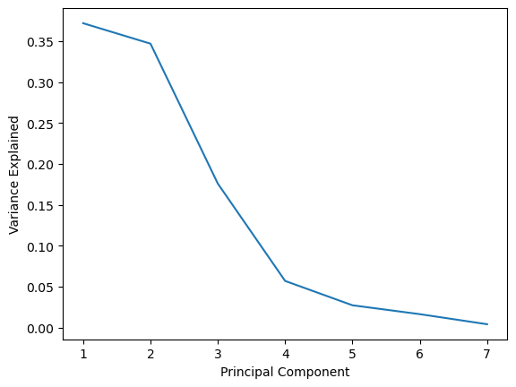

```python
plt.plot(range(1, n_comps + 1), pca.explained_variance_ratio_)
plt.xlabel("Principal Component")
plt.ylabel("Variance Explained")
plt.show()
```

```python
sum(pca.explained_variance_ratio_[0:4])
```

```
0.9520883911037916
```

```python
df_proc = df_pca.loc[:, ['PCA_1', 'PCA_2', 'PCA_3', 'PCA_4']]
df_proc.head()
```

| coin_id | PCA_1 | PCA_2 | PCA_3 | PCA_4 |
| --- | --- | --- | --- | --- |
| bitcoin | -0.600667 | 0.842760 | 0.461595 | -0.109151 |
| ethereum | -0.458261 | 0.458466 | 0.952877 | 0.095100 |
| tether | -0.433070 | -0.168126 | -0.641752 | -0.470282 |
| ripple | -0.471835 | -0.222660 | -0.479053 | -0.737473 |
| bitcoin-cash | -1.157800 | 2.041209 | 1.859715 | 0.236479 |

#### Answer the following question:

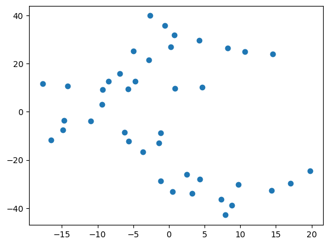

```python
# TSNE on PCA

X = df_proc.to_numpy()
X_embedded = TSNE(perplexity=5).fit_transform(X)

plt.scatter(X_embedded[:, 0], X_embedded[:, 1])
plt.show()
```

### Find the Best Value for k Using the PCA Data

```python
# DO K MEANS
inertia = []
silhouettes = []
k = list(range(2, 12))

for i in k:
    print(f"Processing K={i}")
    k_model = KMeans(n_clusters=i, random_state=1)
    k_model.fit(df_proc) # fit on the scaled data
    inertia.append(k_model.inertia_)

    preds = k_model.predict(df_proc)
    silhouette_avg = silhouette_score(df_proc, preds)
    silhouettes.append(silhouette_avg)
```

```
Processing K=2
Processing K=3
Processing K=4
Processing K=5
Processing K=6
Processing K=7
Processing K=8
Processing K=9
Processing K=10
Processing K=11
```

```python
# Define a DataFrame to hold the values for k and the corresponding inertia
elbow_data = {"k": k, "silouehette": silhouettes, "inertia": inertia}
df_elbow = pd.DataFrame(elbow_data)
df_elbow["inertia_diff"] = df_elbow.inertia.diff()
```

```python
# Review the DataFrame
df_elbow
```

|  | k | silouehette | inertia | inertia_diff |
| --- | --- | --- | --- | --- |
| 0 | 2 | 0.667967 | 182.193841 | NaN |
| 1 | 3 | 0.719133 | 110.149077 | -72.044764 |
| 2 | 4 | 0.355127 | 66.035401 | -44.113676 |
| 3 | 5 | 0.297483 | 52.618525 | -13.416876 |
| 4 | 6 | 0.332386 | 41.630404 | -10.988121 |
| 5 | 7 | 0.336464 | 33.041782 | -8.588622 |
| 6 | 8 | 0.272847 | 26.108712 | -6.933070 |
| 7 | 9 | 0.240890 | 22.504424 | -3.604288 |
| 8 | 10 | 0.263989 | 19.205601 | -3.298823 |
| 9 | 11 | 0.243751 | 16.339407 | -2.866194 |

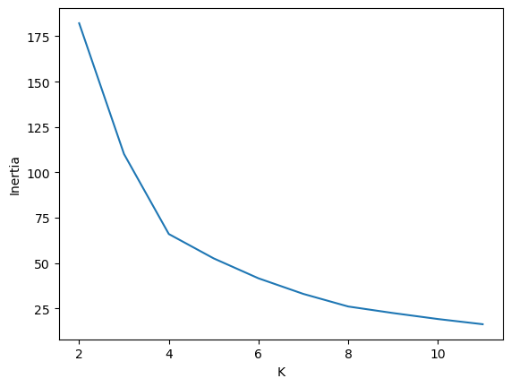

```python
plt.plot(df_elbow.k, df_elbow.inertia)
plt.xlabel("K")
plt.ylabel("Inertia")
plt.show()
```

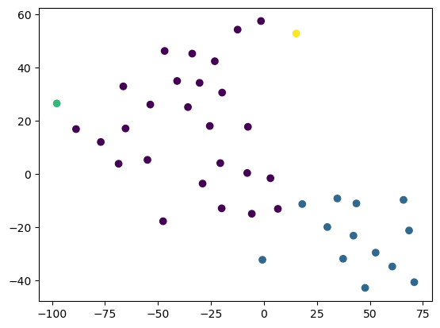

```python
# Make TSNE for 4
model = KMeans(n_clusters=4, random_state=1)

# Fit the model
model.fit(df_proc)

# Make predictions
preds = model.predict(df_proc)

X = df_proc.to_numpy()
X_embedded = TSNE(perplexity=10).fit_transform(X)

plt.scatter(X_embedded[:, 0], X_embedded[:, 1], c=preds)
plt.show()
```

#### Answer the following questions:

- **Question:** What is the best value for `k` when using the PCA data?
  - **Answer:** The best k-value is k=4 when using PCA data
- **Question:** Does it differ from the best k value found using the original data?
  - **Answer:** No, it is the same k value as found using the original data

### Cluster Cryptocurrencies with K-means Using the PCA Data

```python
df_copy2 = df_proc.copy()
df_copy2["cluster"] = preds

df_copy2.cluster.value_counts()
```

```
0    26
1    13
2     1
3     1
Name: cluster, dtype: int64
```

[figure not shown]

```python
plt.scatter(df_copy2.PCA_1, df_copy2.PCA_2, c=df_copy2.cluster)
plt.ylabel("PCA_1")
plt.xlabel("PCA_2")
plt.show()
```

### Visualize and Compare the Results

In this section, you will visually analyze the cluster analysis results by contrasting the outcome with and without using the optimization techniques.

```python
# end
```